# Regression and model validation

*Learning2014 dataset includes information about students who attended the basic statistics course at the end of year 2014. The dataset includes 7 variables and 166 observations. The variables are gender, age, attitude towards statistics, points in the final exam and variables addressing deep, surface, and strategic learning.*

*More information about the dataset can be found [here](http://www.helsinki.fi/~kvehkala/JYTmooc/JYTOPKYS2-meta.txt).*

First, we need to get the dataset to R. I had some problems with my Mac (even though I double checked it like thousand times in the “Data wrangling” part), so I decided to download it via link.

```r
setwd("~/Documents/GitHub/IODS-project/data")
learning2014 <- read.table("http://s3.amazonaws.com/assets.datacamp.com/production/course_2218/datasets/learning2014.txt",
                           sep = ",", header = T)
```

### Overview of the data

Second, we need to have an access to *ggplot2* and *GGally*-packages. Remember to install them first!

```r
library(ggplot2)
library(GGally)
```

Next, let’s see how the data looks like.

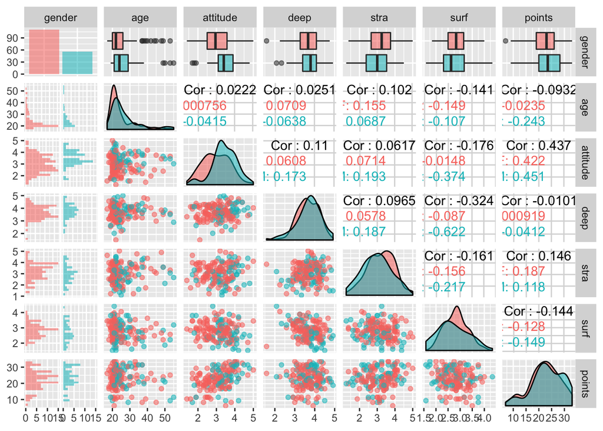

```r
plot1 <- ggpairs(learning2014, mapping = aes(col = gender, alpha = 0.3), lower = list(combo = wrap("facethist", bins = 20)))
plot1
```

Here are some main points about the output:

- Most of the participants are women in their twenties.
- The highest correlation is between attitude and point, addressing that a good attitude towards statistics and/or the course is associated with higher points in the final exam.
- The lowest correlation is between deep learning strategy and point, indicating that they have nothing to do with each others.

### Regression model

Now we could examine a bit do gender, age, and attitude predict points in the final exam.

```r
points_model <- lm(points ~ gender + age + attitude, data = learning2014)
summary(points_model)
```

```
##
## Call:
## lm(formula = points ~ gender + age + attitude, data = learning2014)
##
## Residuals:
##      Min       1Q   Median       3Q      Max
## -17.4590  -3.3221   0.2186   4.0247  10.4632
##
## Coefficients:
##             Estimate Std. Error t value Pr(>|t|)
## (Intercept) 13.42910    2.29043   5.863 2.48e-08 ***
## genderM     -0.33054    0.91934  -0.360    0.720
## age         -0.07586    0.05367  -1.414    0.159
## attitude     3.60657    0.59322   6.080 8.34e-09 ***
## ---
## Signif. codes:  0 '***' 0.001 '**' 0.01 '*' 0.05 '.' 0.1 ' ' 1
##
## Residual standard error: 5.315 on 162 degrees of freedom
## Multiple R-squared:  0.2018, Adjusted R-squared:  0.187
## F-statistic: 13.65 on 3 and 162 DF,  p-value: 5.536e-08
```

In the model above, only attitude is statistically significant variable with p-value < .001. The model shows that better attitude towards statistics/course precits higher points in the exam. Because gender and age are not significant variables, we can remove them from the model and run the model again only with attitude-variable.

```r
points_att <- lm(points ~ attitude, data = learning2014)
summary(points_att)
```

```
##
## Call:
## lm(formula = points ~ attitude, data = learning2014)
##
## Residuals:
##      Min       1Q   Median       3Q      Max
## -16.9763  -3.2119   0.4339   4.1534  10.6645
##
## Coefficients:
##             Estimate Std. Error t value Pr(>|t|)
## (Intercept)  11.6372     1.8303   6.358 1.95e-09 ***
## attitude      3.5255     0.5674   6.214 4.12e-09 ***
## ---
## Signif. codes:  0 '***' 0.001 '**' 0.01 '*' 0.05 '.' 0.1 ' ' 1
##
## Residual standard error: 5.32 on 164 degrees of freedom
## Multiple R-squared:  0.1906, Adjusted R-squared:  0.1856
## F-statistic: 38.61 on 1 and 164 DF,  p-value: 4.119e-09
```

The attitude is still highly significant and it explains 19 % of the value of points (R-square). Note, that the R-square value did not change much when the two other variables were removed from the model.

### Diagnostic plots

Last, after fitting the model and intepreting the results, we should check the diagnostic plots. The following commands do the trick:

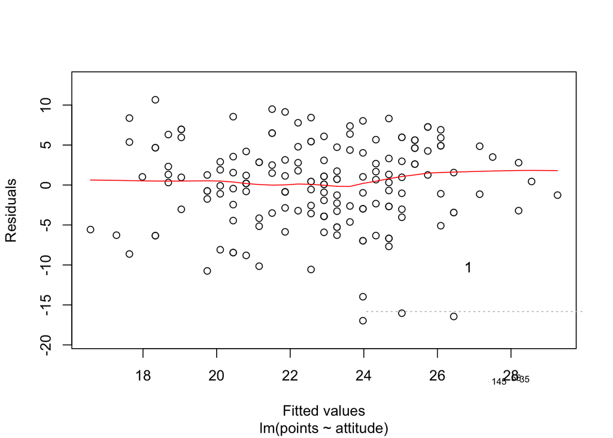

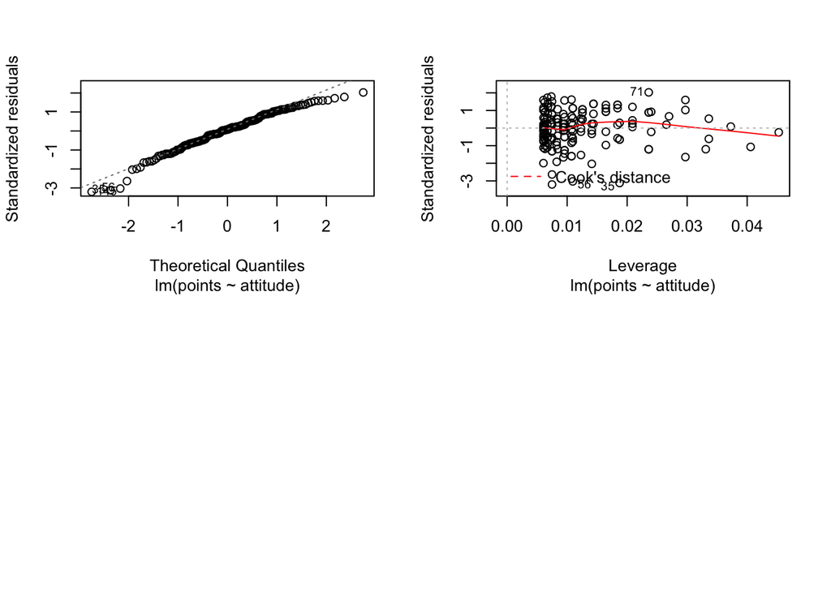

```r
points_att <- lm(points ~ attitude, data = learning2014)
plot(points_att, which = c(1, 2, 5), par(mfrow = c(2,2)))
```

All plots shows that the residuals are nicely spread on both sides of 0 (Residuals vs Fitted values), follow the line well and are (quite) normally distributed (Normal QQ-plot), and the few outliers do not influence the analysis too much (Residuals vs Leverage). The plots indicate that our model fit well to the data and the association between attitude and points is linear (as it should be when using linear regression).